# publication ready viz

The dataset is provided as `practicalgg::happy`. Let’s look at its table form and basic density plot.

```r
data_health = happy %>%
  dplyr::select(age, health) %>%
  na.omit() %>%
  mutate(health = fct_rev(health)) # revert factor order
data_health
```

```
## # A tibble: 38,361 × 2
##      age health
##    <dbl> <fct>
##  1    23 good
##  2    70 fair
##  3    48 excellent
##  4    27 good
##  5    61 good
##  6    26 good
##  7    28 excellent
##  8    27 good
##  9    21 excellent
## 10    30 fair
## # ℹ 38,351 more rows
```

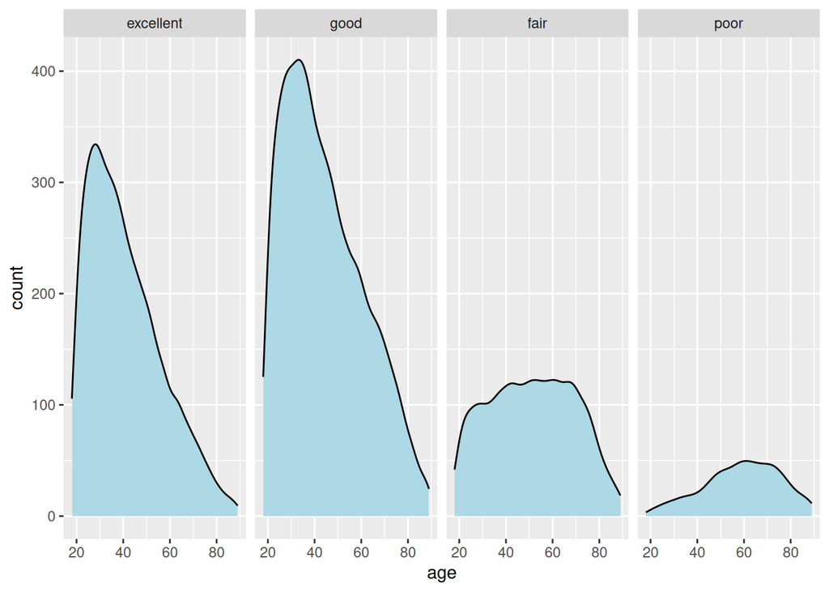

```r
ggplot(data_health, aes(x = age, y = stat(count))) +
  geom_density(fill = "lightblue") +
  facet_wrap(~health, nrow = 1)
```

Add the overall distribution as a background.

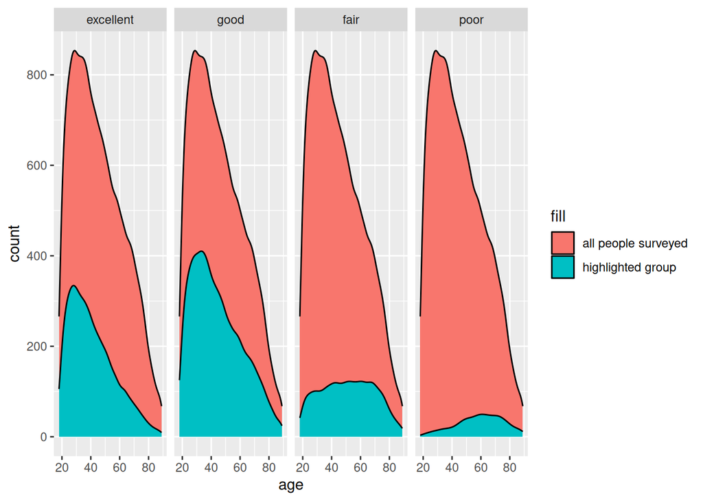

```r
ggplot(data_health, aes(x = age, y = stat(count))) +
  geom_density(
    data = select(data_health, -health),
    aes(fill = "all people surveyed")
  ) +
  geom_density(aes(fill = "highlighted group")) +
  facet_wrap(~health, nrow = 1)
```

Define the scales

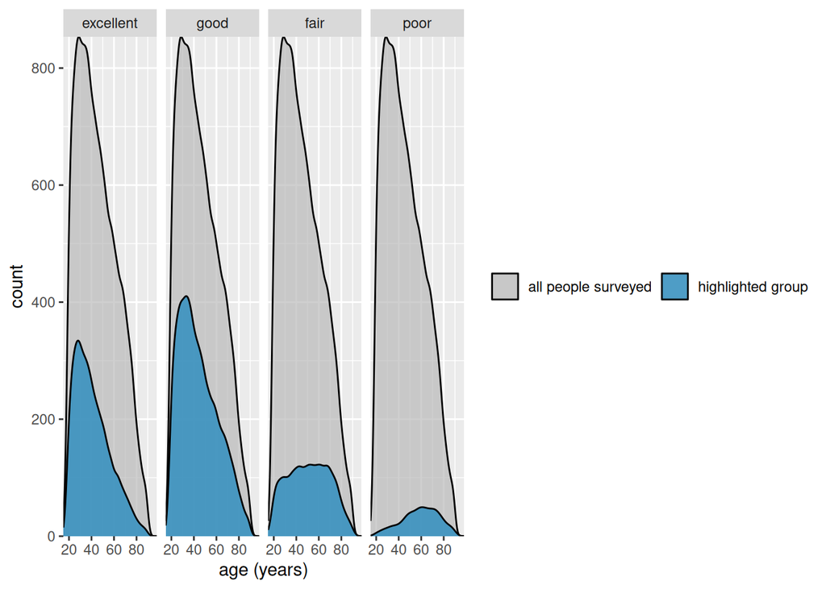

```r
ggplot(data_health, aes(x = age, y = stat(count))) +
  geom_density(
    data = select(data_health, -health),
    aes(fill = "all people surveyed")
  ) +
  geom_density(aes(fill = "highlighted group")) +

  scale_x_continuous(
    name = "age (years)",
    limits = c(15, 98),
    expand = c(0, 0)
  ) +
  scale_y_continuous(
    name = "count",
    expand = c(0, 0)
  ) +
  scale_fill_manual(
    values = c("#b3b3b3a0", "#2b8cbed0"),
    name = NULL,
    guide = guide_legend(direction = "horizontal")
  ) +
  facet_wrap(~health, nrow = 1)
```

Basic theme; move legend to bottom; remove outline around densities.

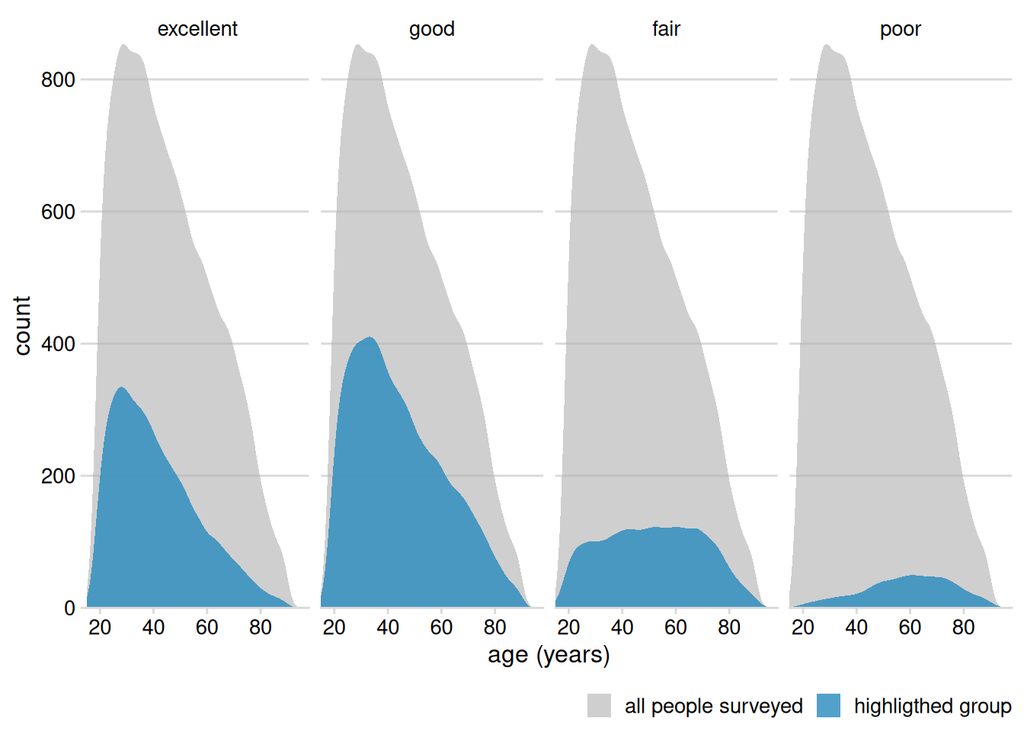

```r
ggplot(data_health, aes(x = age, y = stat(count))) +
  geom_density(
    data = select(data_health, -health),
    aes(fill = "all people surveyed"),
    color = NA
  ) +
  geom_density(aes(fill = "highligthed group"), color = NA) +
  scale_x_continuous(
    name = "age (years)",
    limits = c(15, 98),
    expand = c(0, 0)
  ) +
  scale_y_continuous(
    name = "count",
    expand = c(0, 0)
  ) +
  scale_fill_manual(
    values = c("#b3b3b3a0", "#2b8cbed0"),
    name = NULL,
    guide = guide_legend(direction = "horizontal")
  ) +
  facet_wrap(~health, nrow = 1) +
  theme_minimal_hgrid(12) +
  theme(
    legend.position = "bottom",
    legend.justification = "right"
  )
```

Theme tweaks, Larger strip labels, move legend closer to plot, adjust horizontal legend spacing.

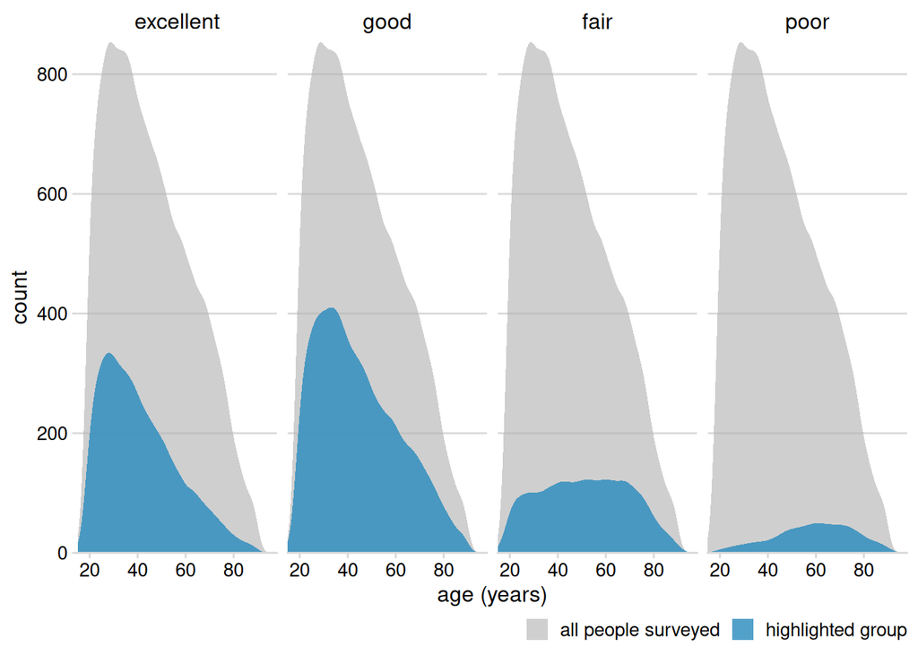

```r
ggplot(data_health, aes(x =  age, y = stat(count))) +
  geom_density(
    data = select(data_health, -health),
    aes(fill = "all people surveyed"),
    color = NA
  ) +
  geom_density(aes(fill = "highlighted group"), color = NA) +
  scale_x_continuous(
    name = "age (years)",
    limits = c(15, 98),
    expand = c(0, 0)
  ) +
  scale_y_continuous(
    name = "count",
    expand = c(0, 0)
  ) +
  scale_fill_manual(
    values = c("#b3b3b3a0", "#2b8cbed0"),
    name = NULL,
    guide = guide_legend(direction = "horizontal")
  ) +
  facet_wrap(~health, nrow = 1) +
  theme_minimal_hgrid(12) +
  theme(
    strip.text = element_text(size = 12, margin = margin(0, 0, 6, 0, "pt")),
    legend.position = "bottom",
    legend.justification = "right",
    legend.margin = margin(6, 0, 1.5, 0, "pt"),
    legend.spacing.x = grid::unit(3, "pt"),
    legend.spacing.y = grid::unit(0, "pt"),
    legend.box.spacing = grid::unit(0, "pt")
  )
```

Remove axis line, add spacing between legend items.

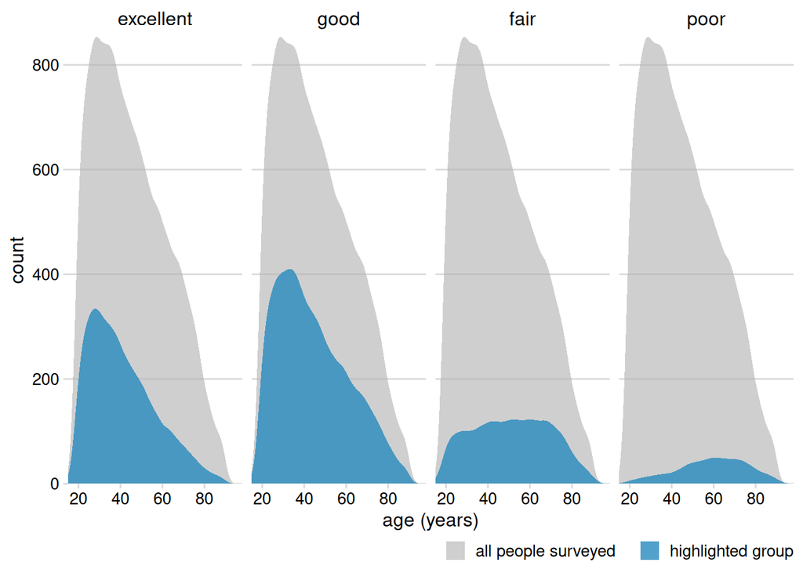

```r
ggplot(data_health, aes(x = age, y = stat(count))) +
  geom_density(
    data = select(data_health, -health),
    # a simple workaround to a limitation in ggplot2:
    # add a few spaces at the end of the legend text
    # to space out the legend items
    aes(fill = "all people surveyed   "),
    color = NA
  ) +
  geom_density(aes(fill = "highlighted group"), color = NA) +
  scale_x_continuous(
    name = "age (years)",
    limits = c(15, 98),
    expand = c(0, 0)
  ) +
  scale_y_continuous(
    name = "count",
    expand = c(0, 0)
  ) +
  scale_fill_manual(
    values = c("#b3b3b3a0", "#2b8cbed0"),
    name = NULL,
    guide = guide_legend(direction = "horizontal")
  ) +
  facet_wrap(~health, nrow = 1) +
  theme_minimal_hgrid(12) +
  theme(
    axis.line = element_blank(),
    strip.text = element_text(size = 12, margin = margin(0, 0, 6, 0, "pt")),
    legend.position = "bottom",
    legend.justification = "right",
    legend.margin = margin(6, 0, 1.5, 0, "pt"),
    legend.spacing.x = grid::unit(3, "pt"),
    legend.spacing.y = grid::unit(0, "pt"),
    legend.box.spacing = grid::unit(0, "pt")
  )
```

Turn off clipping

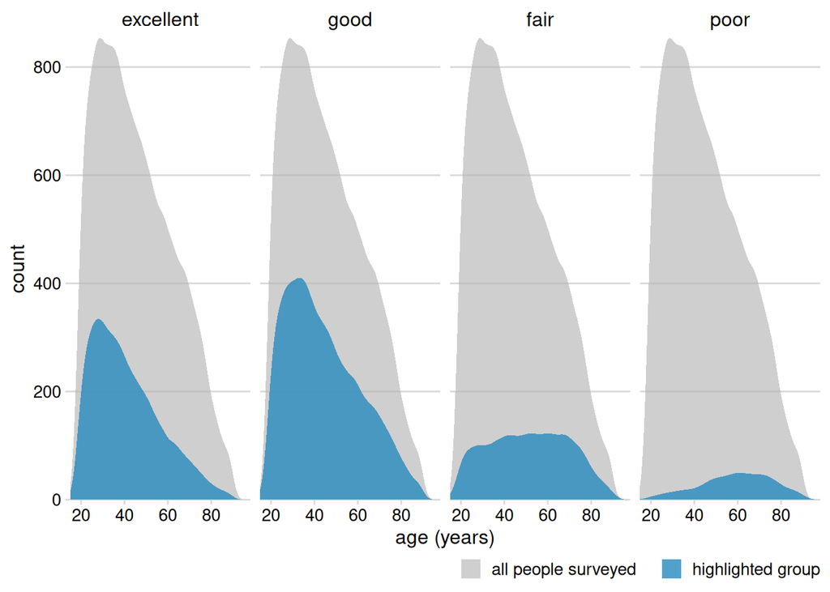

```r
ggplot(data_health, aes(x = age, y = stat(count))) +
  geom_density(
    data = select(data_health, -health),
    aes(fill = "all people surveyed   "),
    color = NA
  ) +
  geom_density(aes(fill = "highlighted group"), color = NA) +
  scale_x_continuous(
    name = "age (years)",
    limits = c(15, 98),
    expand = c(0, 0)
  ) +
  scale_y_continuous(
    name = "count",
    expand = c(0, 0)
  ) +
  scale_fill_manual(
    values = c("#b3b3b3a0", "#2b8cbed0"),
    name = NULL,
    guide = guide_legend(direction = "horizontal")
  ) +
  facet_wrap(~health, nrow = 1) +
  coord_cartesian(clip = "off") +
  theme_minimal_hgrid(12) +
  theme(
    axis.line = element_blank(),
    strip.text = element_text(size = 12, margin = margin(0, 0, 6, 0, "pt")),
    legend.position = "bottom",
    legend.justification = "right",
    legend.margin = margin(6, 0, 1.5, 0, "pt"),
    legend.spacing.x = grid::unit(3, "pt"),
    legend.spacing.y = grid::unit(0, "pt"),
    legend.box.spacing = grid::unit(0, "pt")
  )
```